# How Wet is this Planet?

R Pruim

Spring, 2017

# Collecting some data

How can we estimate proportion of the earth is covered with water? One option would be to sample points on earth, and then to visit them to see whether they are water or land. Much faster and cheaper is to use google maps for this.

Here’s some R code that will sample lat lon points on earth.

```r
require(mosaic)
Points <- rgeo(9)      #  9 random locations
Points
```

```
##         lat        lon
## 1  28.69834  -12.47263
## 2 -25.97005  -90.16982
## 3  18.42754  -24.68391
## 4  30.79100  -82.86828
## 5 -10.31798 -122.51894
## 6 -11.05981   87.92234
## 7 -27.15870   20.68314
## 8 -65.88485  153.37088
## 9 -37.52991   92.27555
```

The data are stored in a **data frame** one of several **containers** R uses to hold related bits of data. Data frames are arranged in rows and columns. Each row is a case, each column is a variable. In this example, we have nine cases, and for each one we have values for two variables (`lat` and `lon`).

Now we can use Google maps to see whether each point is on land or water.

```r
googleMap(position = Points, mark = TRUE)     # open a map for each of them
```

You may need to zoom in or out a bit to be sure you are correctly identifying whether your points are on water or land (and to figure out where in the world you are). Do this and record nine values of 0 (Land) or 1 (Water). Alternatively, we could use text codes for this. The advantage of text is clarity. The advantage of numbers is the ability to do arithmetic. But R lets us convert back and forth pretty easily, so often clarity is the way to go.

You can add your water/land data to this using `mutat()e`.

```r
Points <-
  Points %>%
  mutate(
    water = c(1, 0, 1, 1, 1, 0, 1, 0, 1),
    status = c("W", "L", "W", "W", "W", "L", "W", "L", "W")
  )
Points
```

```
##         lat        lon water status
## 1  28.69834  -12.47263     1      W
## 2 -25.97005  -90.16982     0      L
## 3  18.42754  -24.68391     1      W
## 4  30.79100  -82.86828     1      W
## 5 -10.31798 -122.51894     1      W
## 6 -11.05981   87.92234     0      L
## 7 -27.15870   20.68314     1      W
## 8 -65.88485  153.37088     0      L
## 9 -37.52991   92.27555     1      W
```

We can do some arithmetic with these in either format. Let’s compute the total number of water observations and the proportion that were water observations.

```r
sum(Points$water)                   # $-style
```

```
## [1] 6
```

```r
with(Points, sum(water))            # with() style
```

```
## [1] 6
```

```r
sum( ~ water, data = Points)        # formula style (requires mosaic package)
```

```
## [1] 6
```

```r
sum( ~ (status == "W"), data = Points)
```

```
## [1] 6
```

```r
prop( ~ water, data = Points)       # proportion, requires mosaic package
```

```
##         1
## 0.6666667
```

```r
prop( ~ status, data = Points)      # proportion, requires mosaic package
```

```
##         L
## 0.3333333
```

```r
prop( ~ status, data = Points, level = "W")   # proportion, water-centric
```

```
##         W
## 0.6666667
```

# Bayes estimation

## Big picture

The situation is very similar to the situation with the milk jug lids in the bags. One big difference is that now we don’t have just 5 possible proptions of blue lids (0, 0.25, 0.5, 0.75, or 1.0). This time the proprtion of water could be any number between 0 and 1. We will call this unknown value that we want to estimate a **parameter** (or sometimes the **estimand**).

Our prior and posterior are now **densities** (more technically **probality density functions**).  
Densities are functions that describe probability in the following way:

- the value of the function is always non-negative.
- the total area under the curve is 1. (The value of the function may go above 1 on small regions.)
- the area under the curve over any interval is the probability of a random variable being in that interval.

So where the curve is higher, there is more probability. Where it is lower, there is less.

Avoiding the issues of how we calculate these things. Let’s look at the prior and posterior for our data. We’ll use a uniform prior (all values of $p$ are equally likely), as if we were intergalactic travelers with no prior knowledge about the amount of water on planet earth.

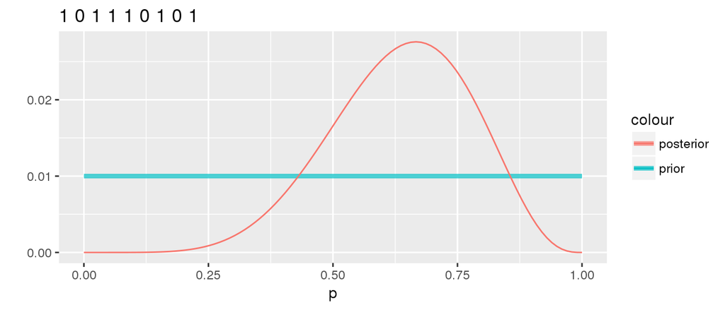

```r
bayes_prop(data = Points$water, p = seq(0, 1, length.out = 100))
```

### Different Priors

Or we could use a prior that reflects that we believe the majority of the planet is water, but otherwise we don’t know anything.

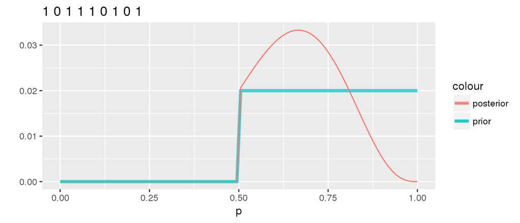

```r
bayes_prop(data = Points$water,
           p = seq(0, 1, length.out = 100),
           prior = as.numeric(seq(0, 1, length.out = 100) > 0.5))
```

Or perhaps we want a prior that says “close to 2/3 water”. Here’s an example that gives all probabilities a chance, but gives probabilities near 2/3 a better chance.

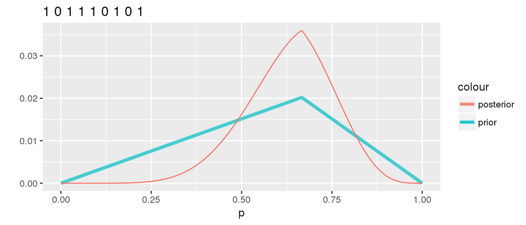

```r
bayes_prop(data = Points$water,
           p = seq(0, 1, length.out = 100),
           prior = triangle::dtriangle(seq(0, 1, length.out = 100), 0, 1, 2/3))
```

### One datum at at a time

We can also build our posterior iteratively, each time adding the new data value using the previous posterior as the new prior.

[figure not shown]

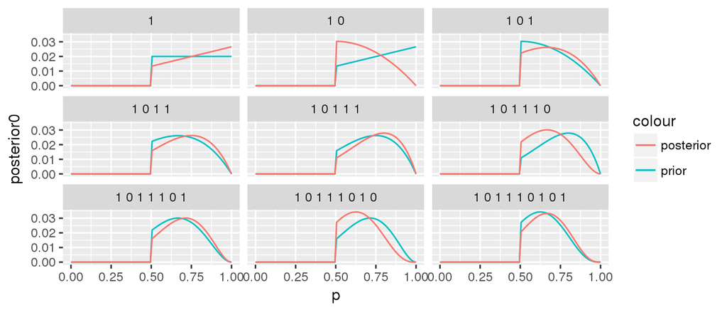

```r
G <-
  Reduce(c, Points$water, accumulate = TRUE) %>%
  lapply(bayes_prop,
         p = seq(0, 1, length.out = 100),
         prior = as.numeric(seq(0, 1, length.out = 100) >= 0.5),
         results = "data") %>%
  bind_rows()

ggplot(G) +
  geom_line(aes(x = p, y = posterior0, color = "prior")) +
  geom_line(aes(x = p, y = posterior, color = "posterior")) +
  facet_wrap(~d)
```

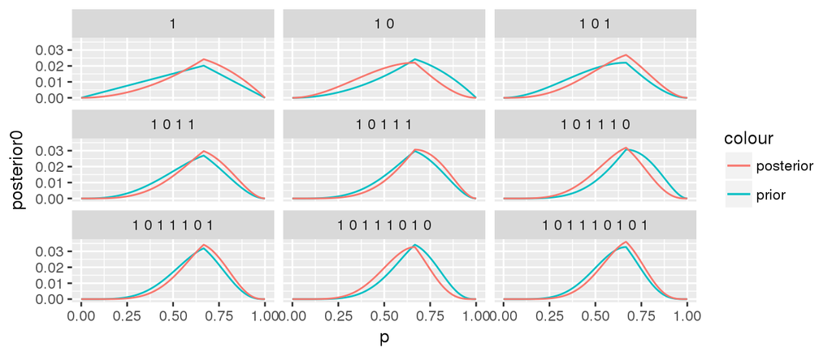

```r
G <-
  Reduce(c, Points$water, accumulate = TRUE) %>%
  lapply(bayes_prop,
         p = seq(0, 1, length.out = 100),
         prior = triangle::dtriangle(seq(0, 1, length.out = 100), 0, 1, 2/3),
         results = "data") %>%
  bind_rows()

ggplot(G) +
  geom_line(aes(x = p, y = posterior0, color = "prior")) +
  geom_line(aes(x = p, y = posterior, color = "posterior")) +
  facet_wrap(~d)
```

## The Grid Method

So how do we convert priors into posteriors that are updated based on our data? In this particular example, those of you who have had Stat 343 would be able to do the calculations to show that when the prior is uniform, then the posterior is beta and to work out the parameters of the beta distribution. But since there are relatively few examples where we can easily derive the posterior as a function, we will focus instead on three computational methods:

- Grid Method
- Quadratic Approximation
- MCMC (using Stan)

The Grid method is the simplest, but can only be practially applied in very limited situations. Becase it is easy and useful for developing an understanding of how Bayesian updating works, it’s a good place to start. Soon we we will come to prefer the otehr methods.

The method is pretty simple:

1. Create a grid of possible parameter values. (In this case, a sequence of values between 0 and 1).

   Useful R functions: `seq()` and `expand.grid()`.
2. At each point in the grid, evaluate/define the prior.

   We will learn more about how to choose a prior later. When there is little information before data are collected, priors tend to be fairly flat over the range of possible parameter values (but when the range of possible paramter values is unbounded, the prioir is not typically completely flat like the uniform prior.)
3. At each point in the grid, evaluate the likelihood.

   The likelihood funciton is the heart of the model. Typically it is generated by some **data story** that describes how data could be generated. (The data story need not be technically correct to generate the correct likelihood function. And the likelihood function doesn’t need to be “correct” to be useful. We will eventually learn some diagnostic tools to see how well our model is performing. For now we will focus on the mechanics.)
4. At each point in the grid, evaluate prior * likelihood.

   This is simple arithmetic.
5. Normalize the posterior
   - easy version: by deviding `prior * likelihood / sum(prior * likelihood)`
   - better version: divide by a constant that makes the area under the cureve = 1 (If the sequence is evenly spaced, as is usually the case, this is the width of the subdivisions in the grid.)

Here’s how to do this for a proportion assuming the following data story:

- $p$ is the actual proprtion of water on earth
- each observation has proportion $p$ of being water (and $1-p$ of being land)
- each observation of water or land is independent of the others

Now let’s build our grid:

```r
BinomGrid <-
  expand.grid(p = seq(0, 1, by = 0.001)) %>%       # create grid of values for p
  mutate(                                             # add additional variables
    prior = 1,                              # uniform prior, value gets recycled
    likelihood = dbinom(6, size = 9, prob = p),            # binomial probabilty
    posterior_raw = prior * likelihood,                    # kernel of posterior
    posterior1 = posterior_raw / sum(posterior_raw),        # easy normalization
    posterior = posterior_raw / sum(posterior_raw) / 0.001 # fancy normalization
  )
head(BinomGrid)
```

```
##       p prior   likelihood posterior_raw   posterior1    posterior
## 1 0.000     1 0.000000e+00  0.000000e+00 0.000000e+00 0.000000e+00
## 2 0.001     1 8.374825e-17  8.374825e-17 8.374825e-19 8.374825e-16
## 3 0.002     1 5.343808e-15  5.343808e-15 5.343808e-17 5.343808e-14
## 4 0.003     1 6.068653e-14  6.068653e-14 6.068653e-16 6.068653e-13
## 5 0.004     1 3.399517e-13  3.399517e-13 3.399517e-15 3.399517e-12
## 6 0.005     1 1.292911e-12  1.292911e-12 1.292911e-14 1.292911e-11
```

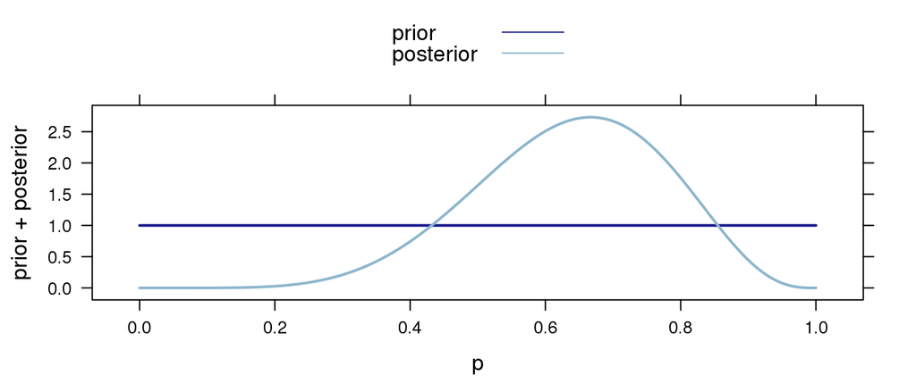

```r
xyplot(prior + posterior ~ p, data = BinomGrid, type = "l", lwd = 2,
       auto.key = list(lines = TRUE, points = FALSE))
```

## What do we do with our posterior?

Three types of questions

1. determine probability in a fixed interval
2. determine an interval with specified probability
3. point estimates (best guesses for a particular purpose)

### Example 1: Is the majority of the world covered by water?

We can answer this question by computing the area under the posterior curver above the interval (0.5, 1.0). But how do we do that? Our posterior is not represented as a function, just a bunch of points.

Our usual approach is to do **posterior sampling**. This is because

- it will work the same for all of our Bayesian updating methods
- it is the only thing available for some Bayesian updating methods
- it is very easy and quite accurate (it works better if we do a larger posterior sample)

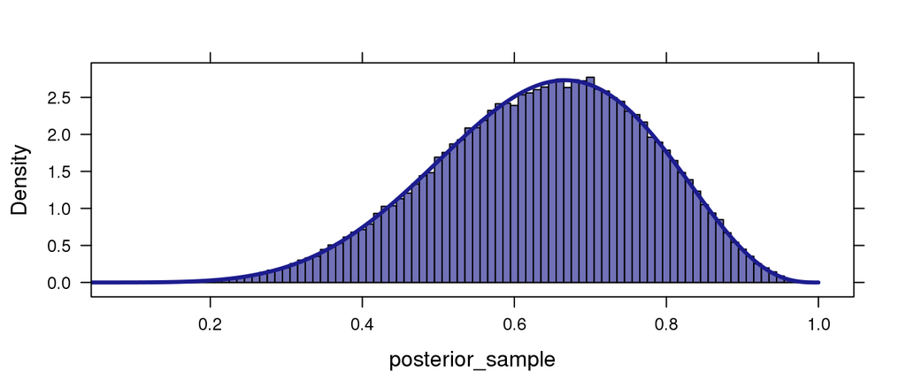

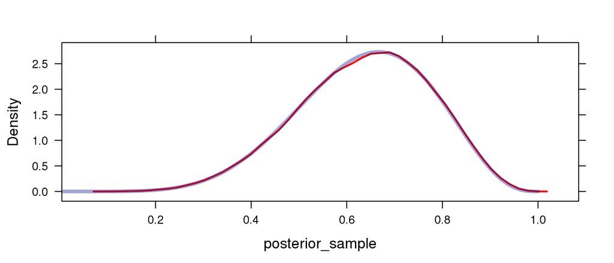

The nice thing about posterior sampling is that we can work with the posterior sample just like we work with regular data. Let’s ask about the proportion above 0.5, for example:

```r
prop( ~ (posterior_sample > 0.5))
```

```
##    TRUE
## 0.82888
```

### Example 2: What is the central 95% of the posterior distribution?

#### Percentile Interval

Idea: trim an equal proportion from each side

```r
# credible interval -- central portion method
cdata(~posterior_sample, 0.95)   # central 95% credible interval
```

```
##       low        hi central.p
##     0.348     0.879     0.950
```

```r
# using PI() function in rethinking package
require(rethinking)
PI(posterior_sample)
```

```
##    5%   94%
## 0.400 0.846
```

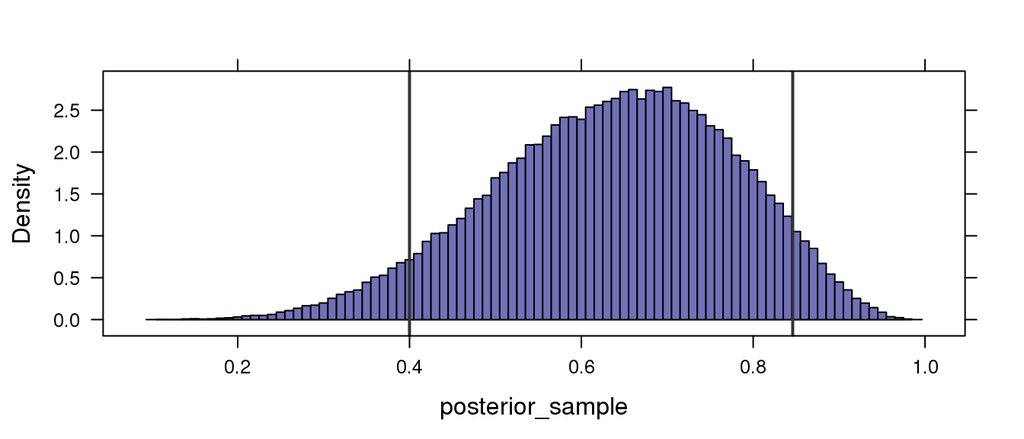

```r
histogram( ~ posterior_sample, width = 0.01, v = PI(posterior_sample))
```

#### Highest Posterior Density Interval

Idea: Chose the portion that has the highest posterior density

- more computationally intensive (but `HPDI()` will do the work for you)
  - we need to smooth the histogram enough that it becomes monotonic or we won’t get a single interval
- higher sampling variance (takes a larger posterior sample to become as stable as PI)
- harder to explain to others

```r
HPDI(posterior_sample)
```

```
## |0.89 0.89|
## 0.413 0.855
```

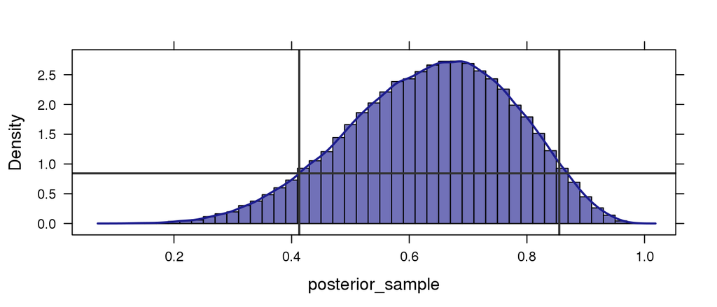

```r
histogram( ~ posterior_sample,
           fit = "kde", dlwd = 2,   # add density plot to histogram with thicker line
           width = 0.02,            # histogram binwidth
           v = HPDI(posterior_sample),
           h = with(BinomGrid, posterior[round(p - HPDI(posterior_sample)[1], 3) == 0])
)
```

## What is our best estimate?

The Bayesian framework delivers a distribution (the posterior density) not a number, but sometimes we need or want to convert it into a number. Which number is the best depends on the use to which it is put. (If one specifies a **loss function**, then for that particular loss function, there is a best number, but without determining the loss function, it isn’t clear what best means.)

Here are three commonly used numbers:

- The mean of the posterior distribution
- The median of the posterior distribution
- The mode (highest point = most density) of the posterior distribution

```r
mean(posterior_sample)
```

```
## [1] 0.637234
```

```r
median(posterior_sample)
```

```
## [1] 0.646
```

```r
chainmode(posterior_sample)
```

```
## [1] 0.6864548
```

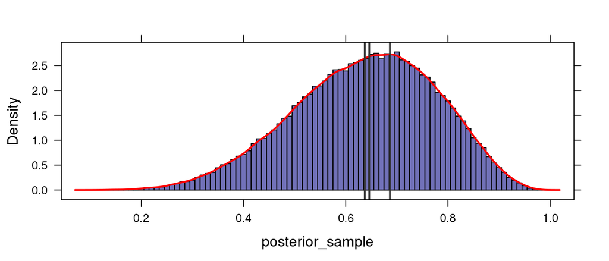

```r
histogram( ~ posterior_sample, fit = "kde", dcol = "red",
           width = 0.01,
           v = c(mean(posterior_sample),
                 median(posterior_sample),
                 chainmode(posterior_sample))
)
```

If the distribution is unimodal and symmetric, all three will give the same value. For a skewed distribution, they may differ. The mode computed using `chainmode()` is actually calculuated not from the raw data but from the smoother version produced by `density()` (and used to produce plots with `densityplot()` and `dens()`).

## Your Turn

Suppose we collect a bit more data. Now we have observed 20 water in 30 observations. Using this data

- Create an appropriate grid using a uniform prior
- Plot the posterior
- Compute the posterior probabity that the majority of the earth is covered with water
- Compute a 95% Percentile Interval (PI) and a 95% Highest Posterior Density Interval (HPDI) for the proprtion of the earth covered with water. How do they compare to teach other? How do they compare to the intervals from our smaller data set? Why?

Bonus: Repeat for another prior of your choice.